# Project Machine Learning Coursera Hopekins

Harry Werder

Thursday, July 09, 2015

### Introduction

We will build a model to predict the outcome “classe” with the levels A,B,C,D,E based on covariants (predictors) from the Human Activity Recognition data. The data for this project comes from this source: http://groupware.les.inf.puc-rio.br/har.

### 1. Step: Set-up of environment in R

```r
setwd("H:/Eigene Dateien/A-Coursera/Stat Kurs/8-Machine Learning/Project") #working directory
rm(list=ls()) #clean the variables
library(ggplot2); library(caret); library(randomForest) #packages used
#Use multiple cores of the processor
# library(doParallel) #install.packages("doParallel")
# registerDoParallel(cores=2)
```

### 2. Step: Loading the data

We load the data and replace all “”,“NA”, “#DIV/0!” values with the NA value from R.

```r
rawdata <- read.csv("pml-training.csv", na.strings = c("", "NA", "#DIV/0!") )
```

### 3. Step: Clean the data and select covariant

We found out by reading the data description that the first seven columns are descriptions. So we remove them from our raw data data. -(1:7).

```r
data <- rawdata[,-(1:7)]
```

We remove now the covariants that have more than 10% of missing data.

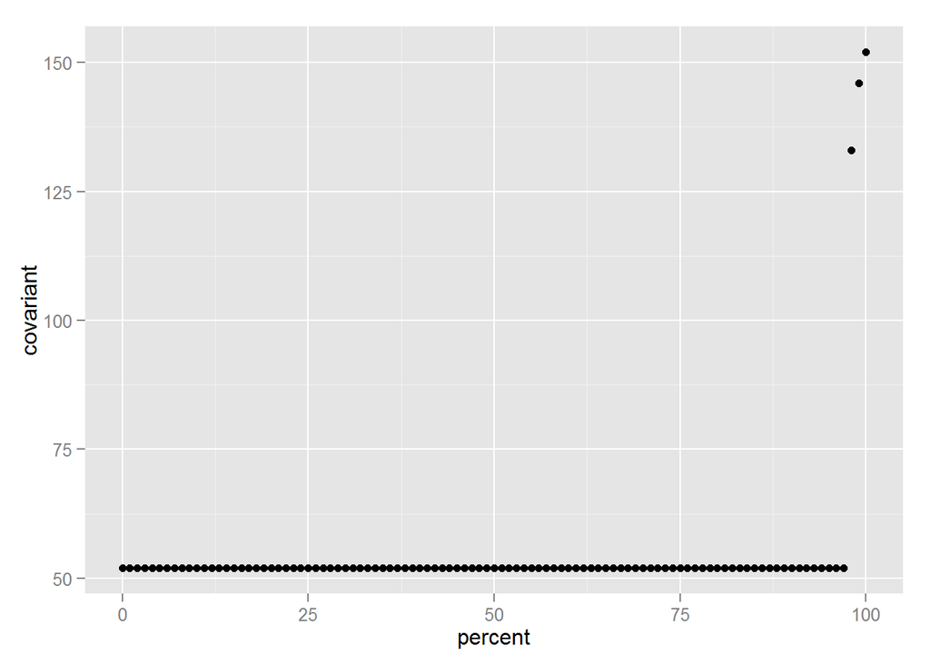

```r
# set the outcome aside
classe <- data$classe
    # remove the classe from the data
        #find the column with the covariants (predictors)
        aa<- colnames(data)=="classe"

    data <- data[,!aa]
# define a function for the removal
remove_cov <- function(x,y) {
    shortdata <- x[ , colSums( is.na(x) ) <= y/100*nrow(x) ]
    bb <- c(i, ncol(shortdata))
    return(bb)
    }
bbb<- data.frame(percent=integer(),covariant=integer()) #initiate
# i is the percentage of NA's per column
for(i in 0:100) {
    bbb[i+1,1]<-remove_cov(data,i)[1]
    bbb[i+1,2]<-remove_cov(data,i)[2]
    }
#the plot tells us what percentage cut-off will reduce covariants
qplot(percent,covariant,data=bbb)
```

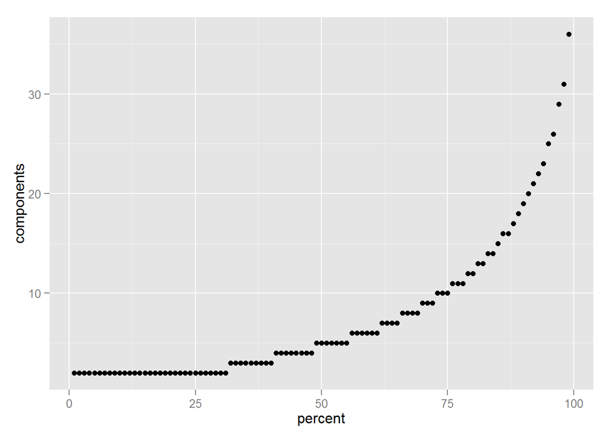

```r
# create our reduced data
shortdata <- data[ , colSums( is.na(data) ) <= 10/100*nrow(data) ]

#reduce by PCA
cc<-data.frame(percent=integer(),components=integer())
for( i in 1:99) {
    pcaFit<-preProcess(shortdata, method=c("center", "scale", "pca"),thresh=i/100)
    cc[i,1]<- i
    cc[i,2]<-pcaFit$numComp
    }
qplot(percent,components,data=cc)
```

```r
pcaFit95<-preProcess(shortdata, method=c("center", "scale", "pca"),thresh=0.95)
pcadata95<-predict(pcaFit95,shortdata)
pcaFit75<-preProcess(shortdata, method=c("center", "scale", "pca"),thresh=0.75)
pcadata75<-predict(pcaFit75,shortdata)

# add the outcome
shortdata$classe <- classe
pcadata95$classe<-classe
pcadata75$classe<-classe
```

We have reduced the number of covariants from **152** to **52**.

```r
yaa <- levels(shortdata$classe)
```

The outcome has the following levels **A, B, C, D, E**.

### 4. Setting up our training and test datasets

We split the data into a training set (70%) and a test set (30%).

```r
set.seed(400)
inTrain <-createDataPartition(y=shortdata$classe, p=0.7, list=FALSE)
training <- shortdata[inTrain,];
testing <- shortdata[-inTrain,]

inTrain95 <-createDataPartition(y=pcadata95$classe, p=0.3, list=FALSE)
training95 <- pcadata95[inTrain95,];
testing95 <- pcadata95[-inTrain95,]

inTrain75 <-createDataPartition(y=pcadata75$classe, p=0.3, list=FALSE)
training75 <- pcadata75[inTrain75,];
testing75 <- pcadata75[-inTrain75,]
```

We have now a training data set with **13737, 53** rows.

### 5. Step: Calculate the model

#### 5.1. Using k-nearest neighbors (knn)

knn-methods is a very simple method. The main parameter is the number of neighbors (=k).

```r
set.seed(400)
ctrl <- trainControl(method="repeatedcv",repeats = 3) #,classProbs=TRUE,summaryFunction = twoClassSummary)
# knnFit <- train(classe ~ ., data = training, method = "knn", trControl = ctrl, preProcess = c("center","scale"), tuneLength = 20)

# saveRDS(knnFit, file="knnFit7030.rds") #save the result
knnFit <- readRDS("knnFit7030.rds")
```

```r
knnplot<- plot(knnFit)
```

#### 5.2 Using random forest method

We chosen random tree as the algorith because it is recognized as a good performer.

```r
# rfFit <- train( classe ~ ., method="rf", prox=TRUE, data=training)
# saveRDS(rfFit, file="rfFit7030.rds")
rfFit <-readRDS("rfFit7030.rds")
tt <- rfFit$finalModel
```

The resulting model

```r
tt
```

```
##
## Call:
##  randomForest(x = x, y = y, mtry = param$mtry, proximity = TRUE)
##                Type of random forest: classification
##                      Number of trees: 500
## No. of variables tried at each split: 27
##
##         OOB estimate of  error rate: 1.75%
## Confusion matrix:
##      A    B    C   D    E class.error
## A 1664    5    3   1    1 0.005973716
## B   20 1108   11   1    0 0.028070175
## C    0   17 1003   7    0 0.023369036
## D    0    1   18 943    3 0.022797927
## E    0    5    5   5 1068 0.013850416
```

OOB looks great with 1.75%!!

We also use next our pca-reduced dataset with less covariants with random tree. One model with 75% variance explained by pca and the other with 95% variance explained.

```r
# it is very timeconsuming to do the train, so I show code and load from file the result
# rfFit95 <- train( classe ~ ., method="rf", prox=TRUE, data=training95)
# saveRDS(rfFit95, file="rfFit953070.rds")
rfFit95 <-readRDS("rfFit953070.rds")
tt95 <- rfFit95$finalModel

# rfFit75 <- train( classe ~ ., method="rf", prox=TRUE, data=training75)
# saveRDS(rfFit75, file="rfFit753070.rds")
rfFit75 <- readRDS("rfFit753070.rds")
tt75 <- rfFit75$finalModel
```

The resulting model for 75% variance explained pca:

```r
tt75
```

```
##
## Call:
##  randomForest(x = x, y = y, mtry = param$mtry, proximity = TRUE)
##                Type of random forest: classification
##                      Number of trees: 500
## No. of variables tried at each split: 2
##
##         OOB estimate of  error rate: 9.63%
## Confusion matrix:
##      A   B   C   D   E class.error
## A 1566  31  31  34  12  0.06451613
## B   46 994  61  20  19  0.12807018
## C   23  38 930  24  12  0.09444985
## D   21  17  70 850   7  0.11917098
## E   16  31  32  22 982  0.09325946
```

```r
tt95
```

```
##
## Call:
##  randomForest(x = x, y = y, mtry = param$mtry, proximity = TRUE)
##                Type of random forest: classification
##                      Number of trees: 500
## No. of variables tried at each split: 2
##
##         OOB estimate of  error rate: 5.81%
## Confusion matrix:
##      A    B   C   D    E class.error
## A 1634   20  13   5    2  0.02389486
## B   40 1053  37   2    8  0.07631579
## C    6   34 955  23    9  0.07010711
## D    5    4  66 885    5  0.08290155
## E    3   19  20  21 1020  0.05817175
```

OOB estimate of error rate is for both model low but fare away from the non adjusted.

### 5. Testing the model with the test data

We use now our testing data to see how good our model works.

Evaluation for pca-reduced models

```r
#our model with PCA at 95% explained, training 30% and 70% test
testaa<- colnames(testing)=="classe"
test95<-testing[,!(testaa)]
testpcadata95<-predict(pcaFit95,test95)
testpcadata95$classe <-testing$classe
pred95<-predict(rfFit95,testpcadata95)
test95conf <- confusionMatrix(testing$classe,pred95)
accrfpca95<-test95conf$overall[1]

#our model with PCA at 75% explained, training 20% and 80% test
test75<-testing[,!(testaa)]
testpcadata75<-predict(pcaFit75,test75)
testpcadata75$classe <-testing$classe
pred75<-predict(rfFit75,testpcadata75)
test75conf <- confusionMatrix(testing$classe,pred75)
accrfpca75<-test75conf$overall[1]
```

Accuracy is for the 75% variance explained pca: **0.9376381** Accuracy is for the 95% variance explained pca: **0.9604078**

Now we test with the full random forest model:

```r
test100<-testing[,!(testaa)]

predrf<-predict(rfFit,test100)
testrfconf <- confusionMatrix(testing$classe,predrf)
accrf<-testrfconf$overall[1]
```

Accuracy is for the full random forest model predication: **0.9872557**

Now we test with the k-nearest neighbors:

```r
# using the test data
# predknn<- predict(knnFit,testing)
# saveRDS(predknn, file="knnFitprdict.rds")
predknn <- readRDS("knnFitprdict.rds")
ttknn<-confusionMatrix(testing$classe, predknn)
accknn<-ttknn$overall[1]
```

Accuracy is for the knn predication: **0.9634664**

Summary We recommend to use random forest model with accuracy of **0.9872557**